# TARASPINA VP | 16S miTags | Eukaryota

Dataset: mapping_SILVA_plus_PhytoRef_plus_CyanoDB_NR99.txt

27.01.2015

# 1) Data overview

Samples with less than 167 reads are removed:

```
## [1] 7206  273
```

```
##       MP0310 MP0311 MP0317 MP0319 MP0320
## OTU_1      0      0      0      0      0
## OTU_2      0      0      1      1      0
## OTU_3      0      1     12     24      0
## OTU_4      2      0      0      1      0
## OTU_5      1      0      1      1      0
```

```
## X124_DCM_0d2.0d45 X124_SUR_0d2.0d45 X125_SUR_0d2.0d45   X36_SUR_0d1.0d2
##               156               107               163                58
##   X37_OMZ_0d2.1d6   X38_OMZ_0d2.1d6   X38_SUR_0d1.0d2   X39_OMZ_0d2.1d6
##               116                49                66                67
##   X39_SUR_0d1.0d2   X41_SUR_0d1.0d2    X7_SUR_0d2.1d6     X93_SUR_0d2.3
##               102                63               154               106
```

Table dimensions and content outline:

```
## [1] 7206  220
```

```
##       MP0310 MP0311 MP0319 MP0321 MP0323
## OTU_1      0      0      0      0      0
## OTU_2      0      0      1      0      0
## OTU_3      0      1     24      0      2
## OTU_4      2      0      1      0      0
## OTU_5      1      0      1      0      0
```

Minimum number of reads per station:

```r
min(colSums(tp_vp_16SmiTags_e_v2))
```

```
## [1] 174
```

Maximum number of reads per station:

```r
max(colSums(tp_vp_16SmiTags_e_v2))
```

```
## [1] 34696
```

Identification of station with higher number of reads:

```r
amplicons_per_sample_tp_vp_16SmiTags_e<-colSums(tp_vp_16SmiTags_e_v2)
amplicons_per_sample_tp_vp_16SmiTags_e[which(colSums(tp_vp_16SmiTags_e_v2)>34600)]
```

```
## X85_DCM_0d2.3
##         34696
```

Overall reads per sample:

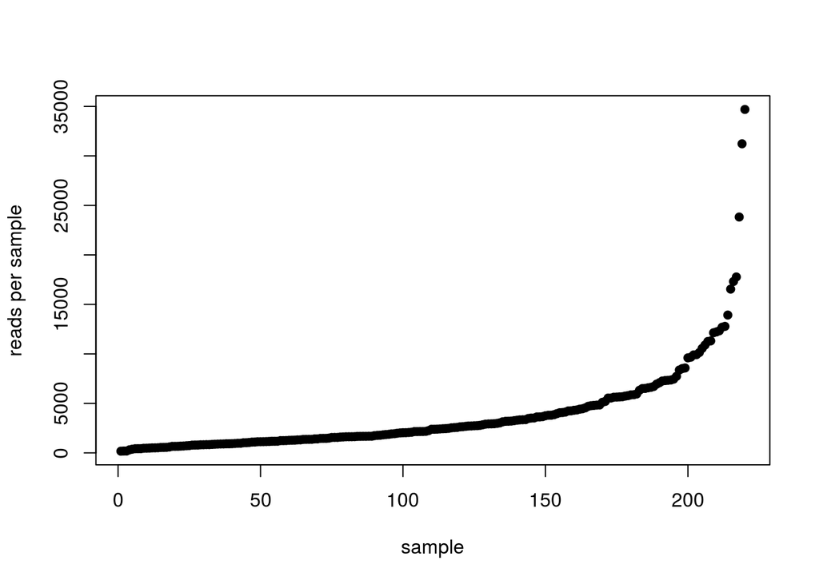

# 2) Normalization to 167 reads per sample

Let’s normalize the original dataset by randomly subsampling 167 reads in each station:

```r
library(vegan)
tp_vp_16SmiTags_e_v2_t<-t(tp_vp_16SmiTags_e_v2)
tp_16mt_e_ss167<-rrarefy(tp_vp_16SmiTags_e_v2_t, 167)
```

The normalized table shows the following dimensions and format:

```
## [1]  220 7206
```

```
##        OTU_1 OTU_2 OTU_3 OTU_4 OTU_5
## MP0310     0     0     0     1     0
## MP0311     0     0     0     0     0
## MP0319     0     0     3     1     1
## MP0321     0     0     0     0     0
## MP0323     0     0     1     0     0
```

Its content fits with the expected normalization values (167 reads per station):

```r
rowSums(tp_16mt_e_ss167)
```

```
##            MP0310            MP0311            MP0319            MP0321
##               167               167               167               167
##            MP0323            MP0528            MP0778            MP0786
##               167               167               167               167
##            MP0888            MP1104            MP1174            MP1176
##               167               167               167               167
##            MP1387            MP1417            MP1421            MP1455
##               167               167               167               167
##            MP1517            MP1527            MP1529            MP1671
##               167               167               167               167
##            MP1672            MP1680            MP1683            MP1684
##               167               167               167               167
##            MP1855            MP1857            MP2239            MP2241
##               167               167               167               167
##            MP2243            MP2376            MP2813            MP2815
##               167               167               167               167
##            MP2819            MP2821             MP581             MP860
##               167               167               167               167
##    X100_DCM_0d2.3    X100_MES_0d2.3    X100_SUR_0d2.3    X102_DCM_0d2.3
##               167               167               167               167
##    X102_MES_0d2.3    X102_SUR_0d2.3    X109_DCM_0d2.3    X109_MES_0d2.3
##               167               167               167               167
##    X109_SUR_0d2.3    X110_DCM_0d2.3    X110_MES_0d2.3    X110_SUR_0d2.3
##               167               167               167               167
##    X111_DCM_0d2.3    X111_MES_0d2.3    X111_SUR_0d2.3    X112_DCM_0d2.3
##               167               167               167               167
##    X112_MES_0d2.3    X112_SUR_0d2.3  X122_DCM_0d1.0d2 X122_DCM_0d2.0d45
##               167               167               167               167
##    X122_DCM_0d2.3 X122_DCM_0d45.0d8  X122_MES_0d1.0d2 X122_MES_0d2.0d45
##               167               167               167               167
##    X122_MES_0d2.3 X122_MES_0d45.0d8  X122_SUR_0d1.0d2 X122_SUR_0d2.0d45
##               167               167               167               167
##    X122_SUR_0d2.3 X122_SUR_0d45.0d8 X123_DCM_0d2.0d45    X123_DCM_0d2.3
##               167               167               167               167
## X123_DCM_0d45.0d8 X123_SUR_0d2.0d45    X123_SUR_0d2.3 X123_SUR_0d45.0d8
##               167               167               167               167
##  X124_DCM_0d1.0d2    X124_DCM_0d2.3 X124_DCM_0d45.0d8  X124_SUR_0d1.0d2
##               167               167               167               167
##    X124_SUR_0d2.3 X124_SUR_0d45.0d8 X125_DCM_0d2.0d45    X125_DCM_0d2.3
##               167               167               167               167
```

[output cut: 55 more lines]

```
##               167               167               167               167
##  X76_MES_0d45.0d8  X76_SUR_0d2.0d45     X76_SUR_0d2.3  X76_SUR_0d45.0d8
##               167               167               167               167
##  X78_DCM_0d2.0d45     X78_DCM_0d2.3  X78_DCM_0d45.0d8     X78_MES_0d2.3
##               167               167               167               167
##  X78_MES_0d45.0d8  X78_SUR_0d2.0d45     X78_SUR_0d2.3  X78_SUR_0d45.0d8
##               167               167               167               167
##    X7_DCM_0d2.1d6     X82_DCM_0d2.3     X82_SUR_0d2.3     X84_SUR_0d2.3
##               167               167               167               167
##     X85_DCM_0d2.3     X85_MES_0d2.3     X85_SUR_0d2.3     X93_DCM_0d2.3
##               167               167               167               167
##     X94_SUR_0d2.3     X96_SUR_0d2.3     X98_DCM_0d2.3     X98_MES_0d2.3
##               167               167               167               167
##     X98_SUR_0d2.3     X99_SUR_0d2.3    X9_DCM_0d2.1d6    X9_SUR_0d2.1d6
##               167               167               167               167
```

Let’s check out how many OTUs don’t appear in the new table:

```r
length(which(colSums(tp_16mt_e_ss167)==0))
```

```
## [1] 3864
```

There are 3864 OTUs that don’t show any occurrence in the normalized data. Let’s remove them from the table and take a look at its final dimensions:

```r
tp_16mt_e_ss167_no_cero<-tp_16mt_e_ss167[,-(which(colSums(tp_16mt_e_ss167)==0))]
dim(tp_16mt_e_ss167_no_cero)
```

```
## [1]  220 3342
```

Datasets summary:

tp_vp_16SmiTags_e_v2_t –> 220 7206

tp_16mt_e_ss167_no_cero –> 220 3342

# 3) General community analysis

## 3.1) Richness and evenness (Shannon index)

Most of the samples take Shannon Index values between 4.25 and 4.75:

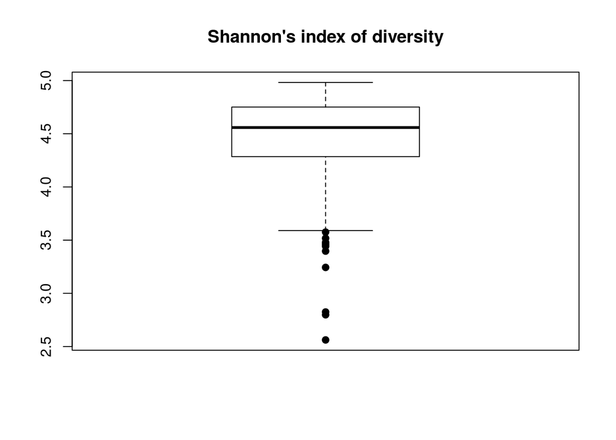

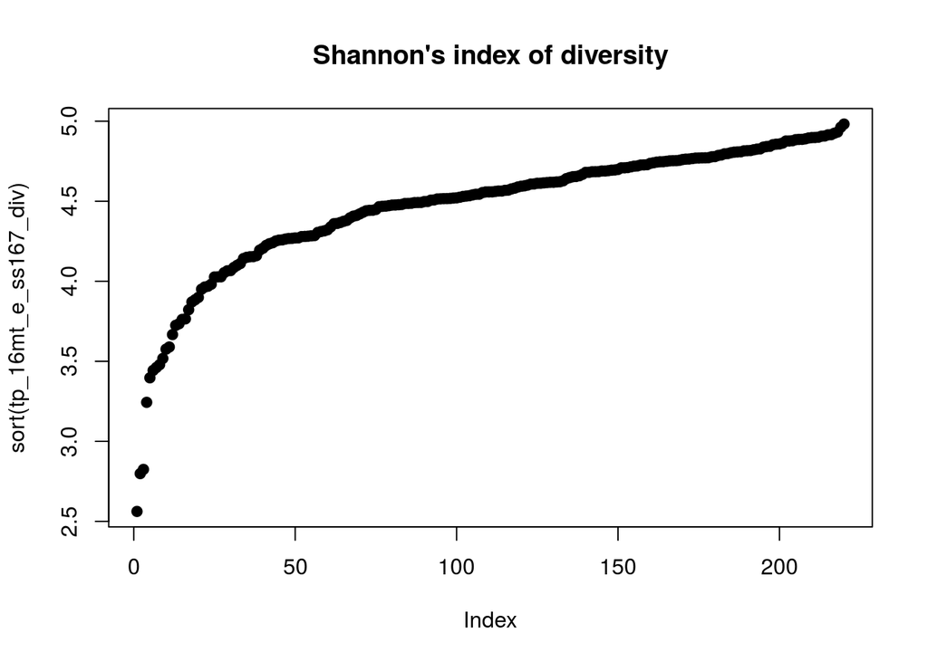

## 3.2) Richness: OTU number

Lowest number of OTUs per sample:

```
## [1] 36
```

Maximum number of OTUs per sample:

```
## [1] 151
```

In most of the samples, we can identify between 100 and 130 OTUs:

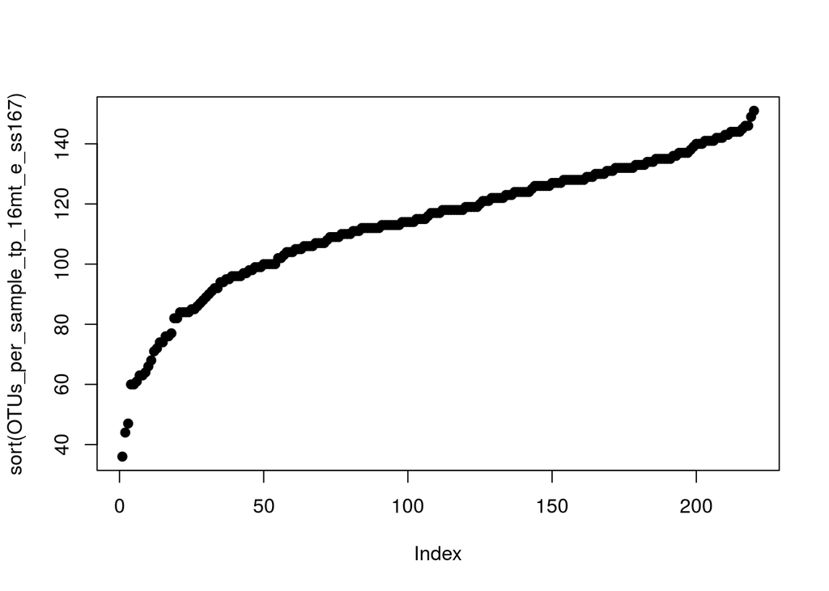

```r
plot(sort(OTUs_per_sample_tp_16mt_e_ss167), pch=19)
```

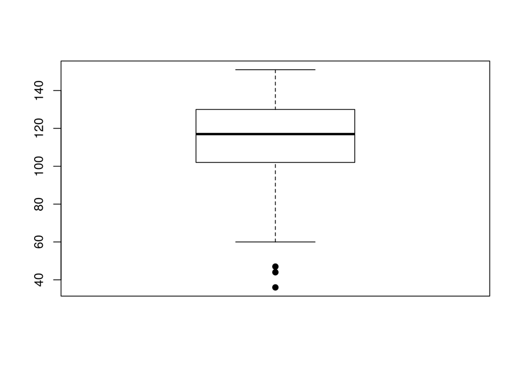

```r
boxplot(OTUs_per_sample_tp_16mt_e_ss167, pch=19)
```

## 3.3) Index of evenness

### 3.3.1) Pielou’s index

```r
pielou_evenness_tp_16mt_e_ss167 <- tp_16mt_e_ss167_div/log(OTUs_per_sample_tp_16mt_e_ss167)
```

The Pielou index (constrained between 0 and 1) takes values closer to 1 as the variation of species proportion in a sample decreases. Most of our samples get values between 0.925 and 0.975, meaning that the numerical composition of different OTUs within our samples is so much similar:

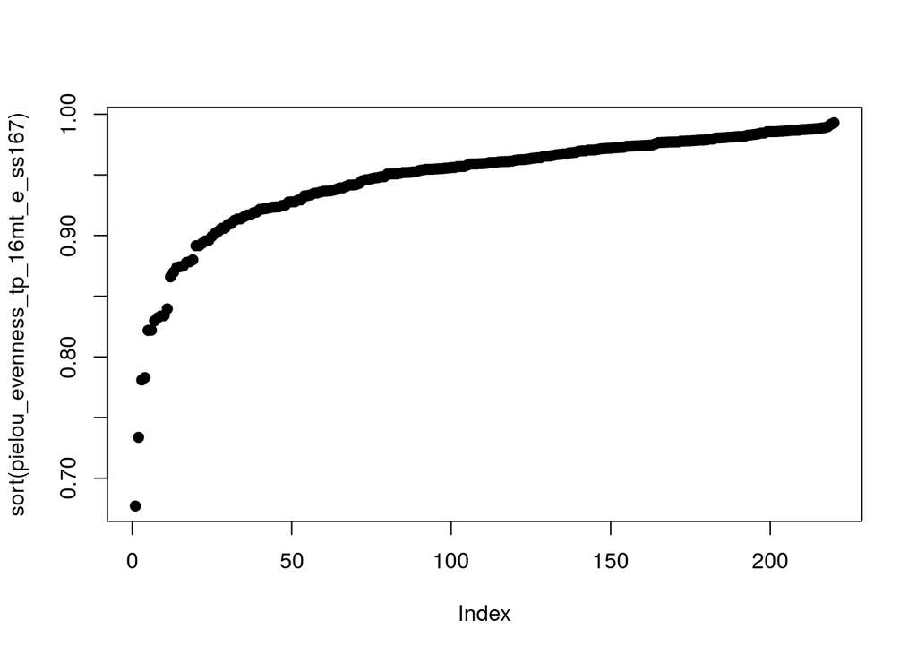

```r
plot(sort(pielou_evenness_tp_16mt_e_ss167), pch=19)
```

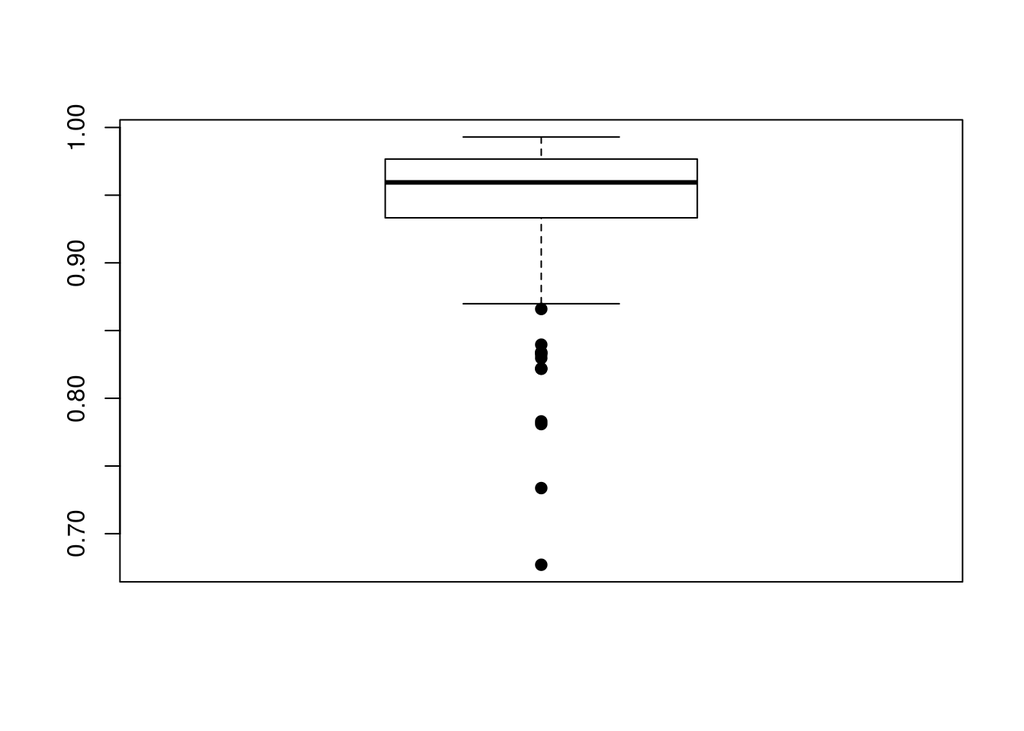

```r
boxplot(pielou_evenness_tp_16mt_e_ss167, pch=19)
```

The OTU_97, with 868 reads, is the most abundant in the overall dataset:

```r
head(sort(colSums(tp_16mt_e_ss167_no_cero), decreasing=T), n=10L)
```

```
##   OTU_97   OTU_33 OTU_2650 OTU_2169 OTU_1594 OTU_2380   OTU_77   OTU_79
##      868      515      279      234      206      184      179      179
##  OTU_108 OTU_2627
##      175      171
```

Most of the OTUs show few occurrences, but we might not be able to identify a significant amount of rare OTUs:

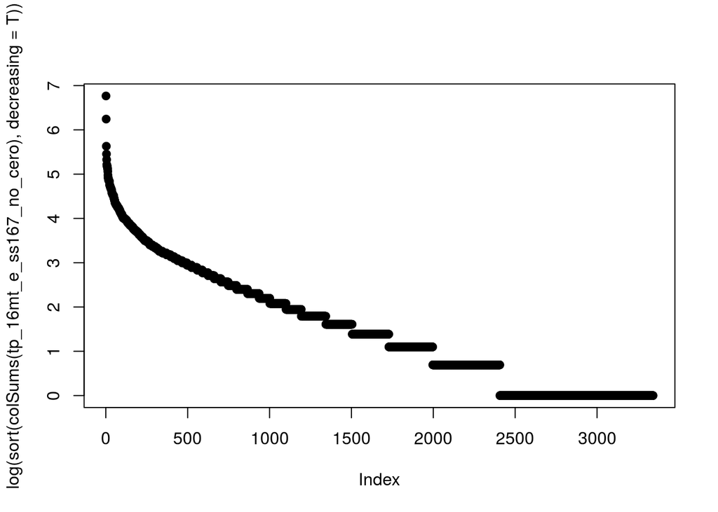

```r
plot(log(sort(colSums(tp_16mt_e_ss167_no_cero), decreasing=T)), pch=19)
```

## 3.4) Abundance Models

### 3.4.2) Preston’s Lognormal Model

According to Preston’s lognormal model fit into species frequencies groups, we’re missing ~2274 species:

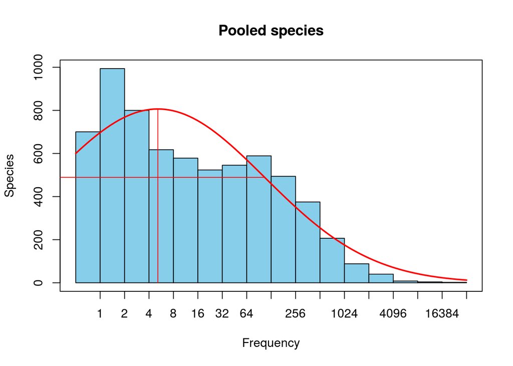

```r
tp_16mt_e_ss167_prestonfit<-prestonfit(colSums(tp_vp_16SmiTags_e_v2_t))
plot(tp_16mt_e_ss167_prestonfit, main="Pooled species")
```

```r
veiledspec(tp_16mt_e_ss167_prestonfit)
```

```
## Extrapolated     Observed       Veiled
##     8839.985     6566.000     2273.985
```

When computing Preston’s lognormal model fit without pooling data into groups, we seem to miss ~1957 species:

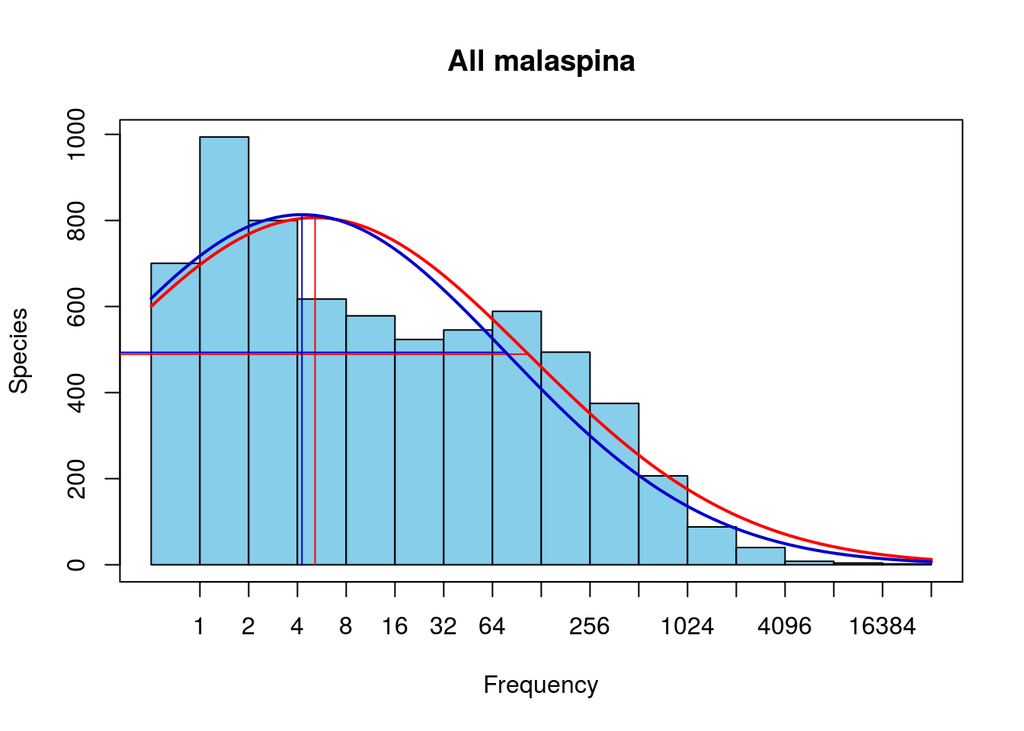

```
## Extrapolated     Observed       Veiled
##     8523.159     6566.000     1957.159
```

## 3.6) Beta diversity

### 3.6.1) Dissimilarity matrix using Bray-Curtis index:

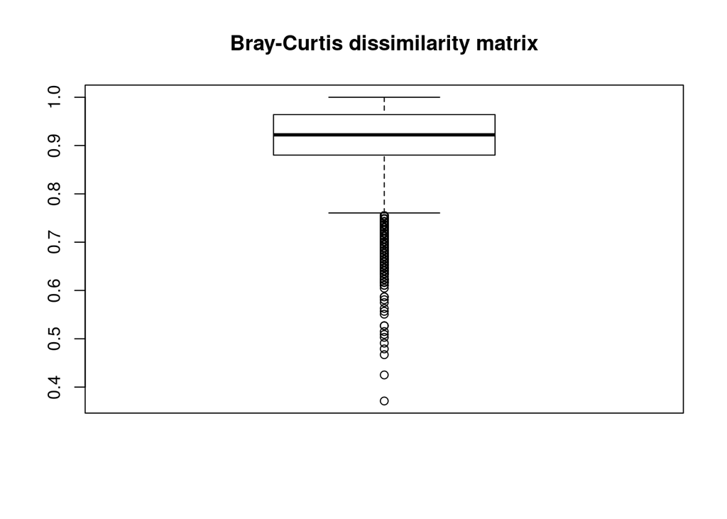

### 3.6.2) Hierarchical clustering

There are no evident clusters that we can distinguish according to the species composition and abundance of the samples.

(To be done: assign Longhurst provinces information to each station and check if any of the central clusters is meaningful regarding to the samples’ geographical ubication)

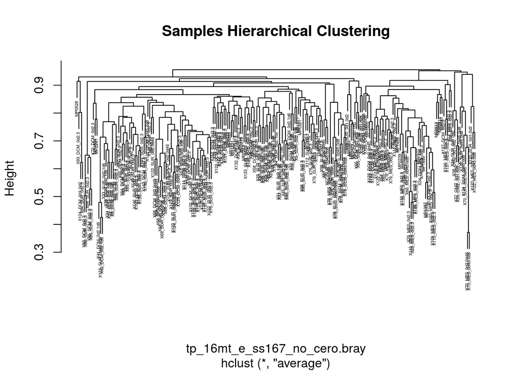

### 3.6.3) Non-metric multidimensional scaling

More of the same… considering the overall distribution, we’re not able to identify any informative clustering pattern.

The stress parameter takes a value below 0.3, meaning that the plot is valid.

```
##
## Call:
## monoMDS(dist = tp_16mt_e_ss167_no_cero.bray)
##
## Non-metric Multidimensional Scaling
##
## 220 points, dissimilarity 'bray', call 'vegdist(x = tp_16mt_e_ss167_no_cero, method = "bray")'
##
## Dimensions: 2
## Stress:     0.2353974
## Stress type 1, weak ties
## Scores scaled to unit root mean square, rotated to principal components
## Stopped after 104 iterations: Stress nearly unchanged (ratio > sratmax)
```

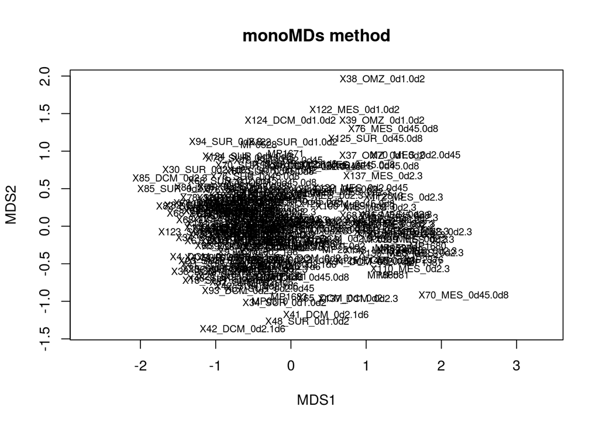

When implementing a most robut function for computing NMDS plots, the result is quiet the same:

```
## ... procrustes: rmse 0.03976582  max resid 0.1696077
```

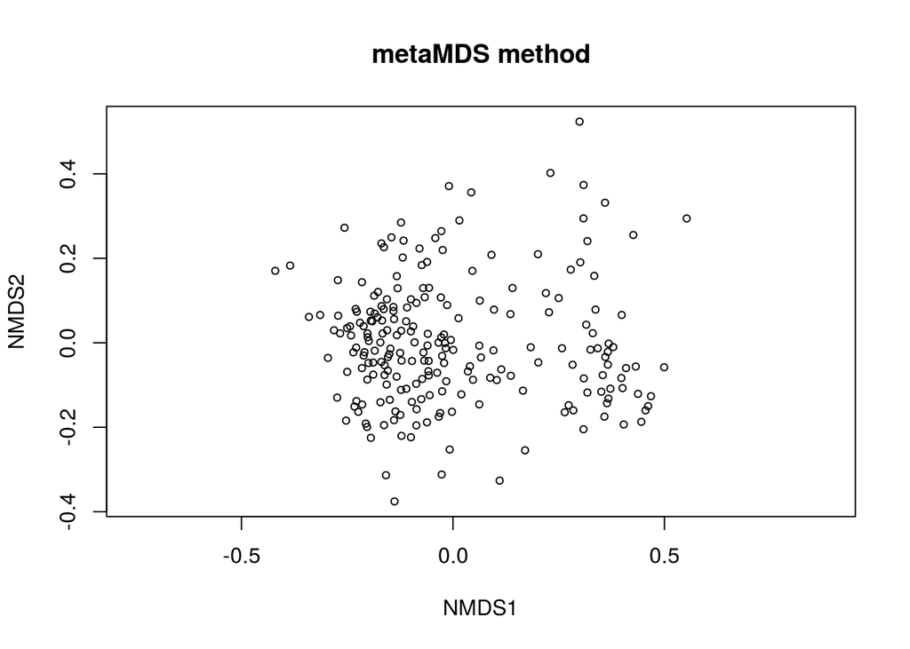

# 4) Geographical analysis

Working datasets:

1. Community matrix: tp_16mt_e_ss167_no_cero

```r
dim(tp_16mt_e_ss167_no_cero)
```

```
## [1]  220 3342
```

```r
tp_16mt_e_ss167_no_cero[1:5, 1:5]
```

```
##        OTU_1 OTU_2 OTU_3 OTU_4 OTU_5
## MP0310     0     0     0     1     0
## MP0311     0     0     0     0     0
## MP0319     0     0     3     1     1
## MP0321     0     0     0     0     0
## MP0323     0     0     1     0     0
```

```r
tp_16mt_e_ss167_no_cero.bray<-as.matrix(tp_16mt_e_ss167_no_cero.bray)
```

3. Stations distances in km: geo_distances_TP_16S_e_ss167

```r
dim(geo_distances_TP_16S_e_ss167)
```

```
## [1] 220 220
```

Communities quickly change their composition across geographical distances:

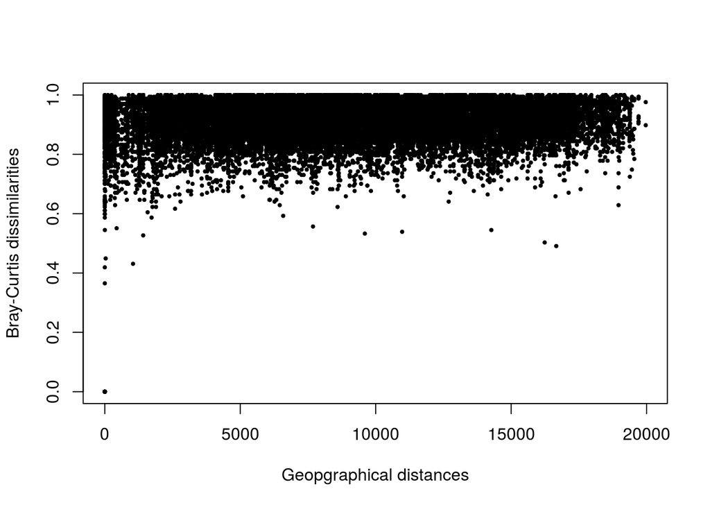

```r
plot(geo_distances_TP_16S_e_ss167, tp_16mt_e_ss167_no_cero.bray, pch=19, cex=0.4, xlab="Geopgraphical distances", ylab="Bray-Curtis dissimilarities")
```

## 4.1) Mantel correlograms

When implementing the Mantel Test, we obtain a very low statistic, meaning that the correlation between samples dissimilarity and geographical distances is weak; however, it is significant, so we can consider the test meaningful.

```r
mantel(geo_distances_TP_16S_e_ss167, tp_16mt_e_ss167_no_cero.bray)
```

```
##
## Mantel statistic based on Pearson's product-moment correlation
##
## Call:
## mantel(xdis = geo_distances_TP_16S_e_ss167, ydis = tp_16mt_e_ss167_no_cero.bray)
##
## Mantel statistic r: 0.1157
##       Significance: 0.001
##
## Upper quantiles of permutations (null model):
##    90%    95%  97.5%    99%
## 0.0163 0.0221 0.0252 0.0311
## Permutation: free
## Number of permutations: 999
```

Maximum distance between samples:

```
## [1] 19969.22
```

Minimum distance between samples:

```
## [1] 0
```

Correlograms:

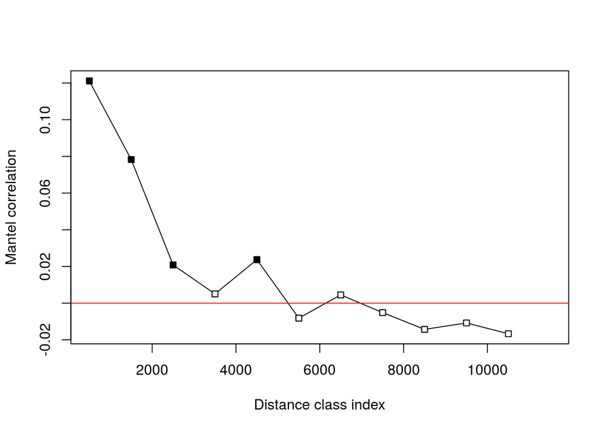

```r
TP_16S_e_ss167_mantel_correl_by_1000km<-mantel.correlog(tp_16mt_e_ss167_no_cero.bray, D.geo=geo_distances_TP_16S_e_ss167, break.pts=seq(0,20000, by=1000))
plot(TP_16S_e_ss167_mantel_correl_by_1000km)
```

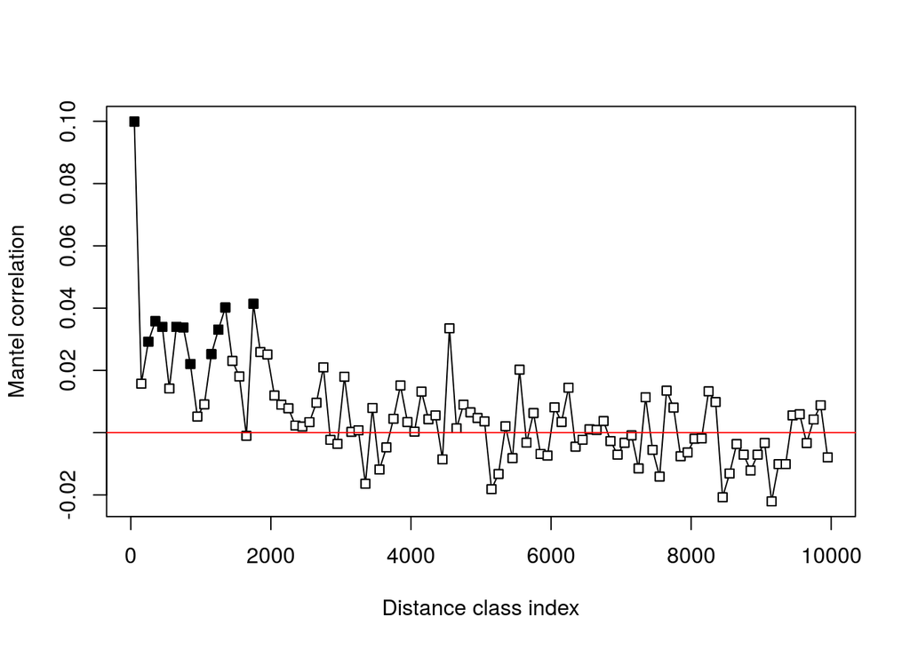

```r
TP_16S_e_ss167_mantel_correl_by_100km<-mantel.correlog(tp_16mt_e_ss167_no_cero.bray, D.geo=geo_distances_TP_16S_e_ss167, break.pts=seq(0,20000, by=100))
plot(TP_16S_e_ss167_mantel_correl_by_100km)
```

# 5) Abundance & occurence

In the following plot, we can appreciate the OTUs distribution according to their percentage of occurence and relative abundance. The blue line restricts regionally abundant OTUs (> 0.1%).

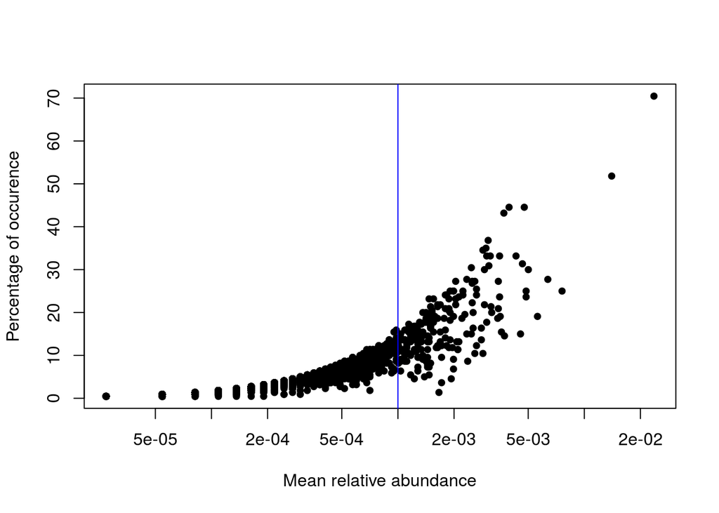

Regionally abundant OTUs (relative abundance over 0.1%):

```
##          mean_rabund perc_occur
## OTU_97   0.023625476  70.454545
## OTU_33   0.014017420  51.818182
## OTU_2650 0.007593903  25.000000
## OTU_2169 0.006369080  27.727273
## OTU_1594 0.005606968  19.090909
## OTU_2380 0.005008165  30.000000
## OTU_79   0.004872074  25.000000
## OTU_77   0.004872074  23.636364
## OTU_108  0.004763201  44.545455
## OTU_2627 0.004654328  31.363636
## OTU_36   0.004545455  15.000000
## OTU_1971 0.004300490  33.181818
## OTU_278  0.003946652  44.545455
## OTU_155  0.003728906  14.545455
## OTU_186  0.003701688  43.181818
## OTU_154  0.003592814  15.454545
## OTU_2197 0.003538378  19.090909
## OTU_1458 0.003511159  33.181818
## OTU_1632 0.003511159  23.636364
## OTU_1170 0.003456723  27.272727
## OTU_26   0.003456723  20.909091
## OTU_2673 0.003429505  18.636364
## OTU_529  0.003184540  20.000000
## OTU_91   0.003157322  21.363636
## OTU_756  0.003130103  33.181818
## OTU_699  0.003075667  30.909091
## OTU_782  0.003048449  36.818182
## OTU_373  0.002994012  33.181818
## OTU_2781 0.002994012  17.727273
## OTU_494  0.002966794  35.000000
## OTU_1933 0.002912357  30.000000
## OTU_801  0.002912357  21.818182
## OTU_1269 0.002857921  34.545455
## OTU_152  0.002857921  10.454545
## OTU_1030 0.002803484  16.363636
## OTU_3457 0.002803484  13.636364
## OTU_1162 0.002640174  25.454545
## OTU_2273 0.002640174  24.090909
## OTU_98   0.002640174  12.272727
```

[output cut: 161 more lines]

```
## OTU_1213 0.001061513  11.363636
## OTU_1831 0.001034295  14.090909
## OTU_786  0.001034295  15.000000
## OTU_380  0.001034295  14.090909
## OTU_1702 0.001034295  11.363636
## OTU_1135 0.001034295   9.090909
## OTU_164  0.001034295   8.636364
## OTU_2628 0.001034295   8.636364
## OTU_844  0.001034295   6.363636
## OTU_1542 0.001007077  14.090909
## OTU_411  0.001007077  13.181818
## OTU_1172 0.001007077  12.272727
## OTU_570  0.001007077  11.818182
## OTU_27   0.001007077  10.909091
## OTU_130  0.001007077   8.181818
```

```r
dim(tp_16mt_e_ss167_abundant_sorted)
```

```
## [1] 215   2
```

Proportion of regionally abundant OTUs (%):

```
## [1] 6.433273
```

Cosmopolitan OTUs (abundance over 0.1% and occurence in more than 80% of samples):

```
## [1] mean_rabund perc_occur
## <0 rows> (or 0-length row.names)
```

```r
dim(tp_16mt_e_ss167_cosmop_sorted)
```

```
## [1] 0 2
```

Proportion of cosmopolitan OTUs (%):

```
## [1] 0
```

Number and proportion (%) of rare OTUs:

```r
dim(tp_16mt_e_ss167_rabund_percoccur[tp_16mt_e_ss167_rabund_percoccur$mean_rabund < 0.00001 & tp_16mt_e_ss167_rabund_percoccur$mean_rabund >0,])
```

```
## [1] 0 2
```

```
## [1] 0
```

We don’t detect any instance of rare or cosmopolitan OTUs.